# 第六周作业参考答案

## 1、新教材2.4 下表中的数据是两场篮球联赛中三分球的进球次数，考察两场联赛三分球得分次数是否存在显著性差异。

```r
#导入数据至dataframe
league1<-c(91,46,108,99,110,105,191,57,34,81)
league2<-c(81,51,63,51,46,45,66,64,90,28)
leaguedata=data.frame(league1,league2)

#查看数据头部
head(leaguedata)
```

| league1 | league2 |
| --- | --- |
| 91 | 81 |
| 46 | 51 |
| 108 | 63 |
| 99 | 51 |
| 110 | 46 |
| 105 | 45 |

### （1）采用符号检验；

确立假设问题为$H_0: 两场联赛三分球得分次数无显著性差异\quad v.s.\quad H_1: 两场联赛三分球得分次数存在显著性差异$

取$\alpha=0.05$，使用符号检验，设联赛$i$中第$j$队的三分球进球数表示为$x_{ij},\quad i=1,2,\quad j=1,2...10$，那么定义联赛1进球大于联赛2的数据量$S^+=\sum\limits_{j=1}^{10}I(x_{1j}>x_{2j})=7$，联赛2进球大于联赛1的数据量$S^-=\sum\limits_{j=1}^{10}I(x_{1j}<x_{2j})=3$，有效数据量$S^++S^-=n'=10$，由此、因此假设问题可以改写为：
$$H_0: S^+=S^-\quad v.s.\quad H_1: S^+\neq S^-$$

小样本下进行符号检验，取$k=min\{S^+,S^-\}$，假设检验的$p$值$p=2P_{binom}(K\leq k|n',p=0.5)=0.34375>\alpha$，因此在显著性水平$\alpha$下不能认为二者具有显著差异。

```r
#联赛1进球大于联赛2的数据量
S_plus=sum(leaguedata$league1>leaguedata$league2)

#联赛2进球大于联赛1的数据量
S_minus=sum(leaguedata$league1<leaguedata$league2)

#有效数据量
n=S_plus+S_minus

#小样本下符号检验
k=min(S_plus,S_minus)
2*pbinom(k,n,0.5)
```

```
## [1] 0.34375
```

### （2）采用配对Wilcoxon符号秩检验；

假设问题为$H_0: 两场联赛三分球得分次数无显著性差异\quad v.s.\quad H_1: 两场联赛三分球得分次数存在显著性差异$

符号检验仅考虑考虑数据在对称中心哪一侧，但Wilcoxon符号秩检验不仅考虑数据在对称中心哪一侧，同时还考虑数据位于对称中心但距离。因此定义$X_i=x_{1i}-x_{2i}$，在零假设下对称中心为0。如果两场联赛三分球得分次数无显著性差异，则$X$的分布的中位数为0，否则不等于0，因此在Wilcoxon符号秩检验下假设问题可以表示为：
$$H_0: M=0\quad v.s.\quad H_0: M\neq 0$$
相应的统计量取值如下表所示，：

```r
#样本取值X
X=leaguedata$league1-leaguedata$league2

#绝对值样本的秩R_{i}^{+}
R=rank(abs(X))

#符号W_i
W=as.numeric(X>0)

#反秩D_i
D=1:length(leaguedata$league1)

#输出表格展示
wil_table=data.frame(id=paste('$X_{',1:length(leaguedata$league1),'}$',sep=''),X,R,W,D)
colnames(wil_table) = c('变量','$X_i$','绝对值样本的秩$R_{i}^{+}$','符号$W_i$','反秩$D_i$')
kable(t(wil_table))
```

| 变量 | $X_{1}$ | $X_{2}$ | $X_{3}$ | $X_{4}$ | $X_{5}$ | $X_{6}$ | $X_{7}$ | $X_{8}$ | $X_{9}$ | $X_{10}$ |
| --- | --- | --- | --- | --- | --- | --- | --- | --- | --- | --- |
| $X_i$ | 10 | -5 | 45 | 48 | 64 | 60 | 125 | -7 | -56 | 53 |
| 绝对值样本的秩$R_{i}^{+}$ | 3 | 1 | 4 | 5 | 9 | 8 | 10 | 2 | 7 | 6 |
| 符号$W_i$ | 1 | 0 | 1 | 1 | 1 | 1 | 1 | 0 | 0 | 1 |
| 反秩$D_i$ | 1 | 2 | 3 | 4 | 5 | 6 | 7 | 8 | 9 | 10 |

取显著性水平$\alpha=0.05$Wilcoxon符号秩统计量为$W^+=\sum_{i=1}^nR_j^+W_j=45$，$W^-=\sum_{i=1}^nR_j^+W_j=10$，其中$W^++W^-=\frac{n(n+1)}{2}=55$。令$W=min(W^+,W^-)=10$，求得$W$的双侧$p$值$p=2P(W<10,n=10)=0.08398438>\alpha=0.05$，因此不能拒绝原假设，不能认为二者具有显著差异，结论与符号检验相同。

```r
W_plus=sum(W*R)
W_minus=sum((1-W)*R)
W=min(W_plus,W_minus)
n=length(leaguedata$league1)

#W的密度函数
dwilxonfun=function(N)
{
  a=c(1,1)# when n=1 frequency of W+=1 or 0
  n=1
  pp=NULL # distribute of all size from 2 to N
  aa=NULL # frequency of all size from 2 to N
  for (i in 2:N)
  {
    t=c(rep(0,i),a)
    a=c(a,rep(0,i))+t
    p=a/(2^i)     #density of wilcox distribut when size=N
  }
  p
}

#双侧p值
#由于W的分布的取值是从0开始的，但数组的下标是从1开始的，因此取1:(W+!)
p=2*sum(dwilxonfun(n)[1:(W+1)])
p
```

```
## [1] 0.08398438
```

此外，R语言提供了直接进行Wilcoxon符号秩检验的函数“wilcox.test”，支持配对样本的检验，下面展示直接调用此函数得到的检验结果，$p$值结果与手工计算相同。

```r
#two.sided表示双侧检验，paired=TRUE表示此次检验是配对样本的检验
wilcox.test(league1,league2,alternative='two.sided',paired=TRUE)
```

```
##
##  Wilcoxon signed rank test
##
## data:  league1 and league2
## V = 45, p-value = 0.08398
## alternative hypothesis: true location shift is not equal to 0
```

### （3）在这些数据中哪个检验更好？为什么？

- 符号检验结果为两者不存在显著性差异，配对Wilcoxon符号秩检验在$95\%$置信水平下也认为两者不存在显著性差异，不过在$90\%$置信水平下可以认为两者存在显著差异
- 我们首先简单地观察一下数据的分布
  - 注意到，得分超过100分的均为第一次联赛，可以直观的感觉到两次比赛存在差异。
  - 而且，第二次联赛超过第一次联赛时，大部分时候都是小幅超过；第一次联赛超过第二次联赛时，大部分时候是大幅超越。
- 故而使用符号检验不能反应两者相差的幅度大小
  - 我们可以认为，在使用在这些数据中，配对Wilcoxon检验更好

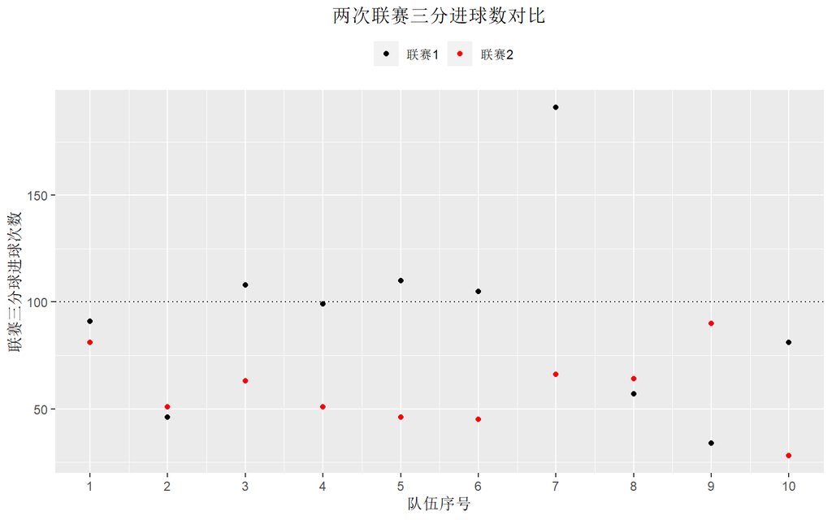

```r
library(ggplot2)
basketball <- read.csv("C:/Users/Lenovo/Desktop/非参作业/2.4basketball.csv", header = T)
p <- ggplot(aes(y = 联赛2, x = 队伍序号), data = basketball) + geom_point(aes(colour = "联赛2"))
# 加入两次的点
p <- p + geom_point(aes(x = 队伍序号, y = 联赛1, colour = "联赛1"))
# 加入分割线
p <- p + geom_hline(yintercept = 100, linetype = 3)
# 加入标签
p <- p + scale_x_continuous(limits=c(1,10), breaks=seq(1, 10, 1)) + ylab("联赛三分球进球次数") + ggtitle("两次联赛三分进球数对比")
# 加入图例
p <- p + scale_colour_manual(values = c("联赛1"="black", "联赛2"="red")) + guides(colour=guide_legend(title=NULL)) + theme(plot.title = element_text(hjust = 0.5), legend.position="top")
print(p)
```

### 2.5 一个监听器收到如下信号，能否说该信号是纯随机干扰？

01011100110000111111111010011101010100 00000010110011101010001001010100000000

取$\alpha=0.05$，进行两类随机游程检验。
$$H_1:该信号是纯随机干扰\quad v.s.\quad H_1:该信号不是纯随机干扰$$

分析数据得$n=76,n_0=42,n_1=34$，游程数$R=37$，在大样本下，利用超几何分布近似正态的均值与方差：
$$E_R=\frac{2n_1n_0}{n_1+n_0}+1$$
$$Var_R=\frac{2n_1n_0(2n_1n_0-n_0-n_1)}{(n_1+n_0)^2(n_1+n_0-1)}$$
$$Z=\frac{R-E_r}{\sqrt{Var_R}}=-0.3688165$$
得到双侧检验的$p$值$p=2P(Z<-0.3688165)=0.7122645>\alpha$，故不能拒绝$H_1$，认为该信号是纯随机干扰。

```r
#以字符串输入
signal_text='0101110011000011111111101001110101010000000010110011101010001001010100000000'

#转换为整数数组
signal=as.numeric(strsplit(signal_text,split='')[[1]])

n=length(signal)#数据长度
n0=sum(signal==0)#0的个数
n1=n-n0#1的个数

#游程个数，即相邻两数变化的次数加一
R=sum(signal[1:(n-1)]!=signal[2:n])+1

#大样本下，利用近似正态分布检验
ER=2*n1*n0/(n1+n0)+1
VarR=2*n1*n0*(2*n1*n0-n0-n1)/((n1+n0)^2*(n1+n0-1))
z=(R-ER)/sqrt(VarR)

#双侧p值
2*pnorm(z)
```

```
## [1] 0.7122645
```

同样，R也提供了封装好的实现两类随机游程检验的函数runs.test，需加载包tseries。这里展示直接调用此函数得到的检验结果，**$p$值结果与手工计算相同**。

```r
library(tseries)#加载tseries包
y=factor(signal)#数组转换为因子（factor）
runs.test(y)#进行随机游程检验（近似正态）
```

```
##
##  Runs Test
##
## data:  y
## Standard Normal = -0.36882, p-value = 0.7123
## alternative hypothesis: two.sided
```

```r
#加载数据
A<-c(92,69,72,40,90,53,85,87,89,88)
B<-c(78,95,58,65,39,67,64,75,60,80,83,96)
```

### （1）wilcoxon秩和检验

$$H_0:A与B无显著差异\quad v.s.\quad H_1:A与B具有显著差异$$

因此不能拒绝原假设，在Wilcoxon秩和检验之下，两种生产效率不具有显著差异。

```r
AB=c(A,B)#合并序列
n1=length(A)#序列A长度
n2=length(B)#序列B长度
n=n1+n2#总长度

R=rank(AB)

R1=sum(R[1:n1])
R2=sum(R[(n1+1):n])
T=R1#T为小样本序列的秩和

U1=n1*n2+n1*(n1+1)/2-T
U2=n1*n2-U1

#检验p值
pwilcox(U1,n1,n2)*2
```

```
## [1] 0.380972
```

R语言进行Wilcoxon秩和检验的函数同样是wilcox.test，但是需要同时输入$x$与$y$两个参数并且设置paired=FALSE（或者不设定paired参数），经过Wilcoxon秩和检验得到$p=0.381>\alpha$，p值结果相同。

关于wilcox.test这一函数，它封装了以Wilcoxon命名的两种非参数检验方法：**秩和检验和符号秩检验。**

- 当只给定一个参数x，或给定两个参数x,y（要求两样本长度相同）并且paired=TRUE时，执行的是符号秩检验（Wilcoxon signed rank test）。
- 当给定两个参数x,y（两样本长度可不同），设定paired=FALSE（或者不设定paired参数），执行的是秩和检验（Wilcoxon rank sum test）。

1（2）使用的是第一种情况，本题属于第二种情况。

```r
wilcox.test(A,B)
```

```
##
##  Wilcoxon rank sum test
##
## data:  A and B
## W = 74, p-value = 0.381
## alternative hypothesis: true location shift is not equal to 0
```

### （2）使用随机游程检验

$$H_0:A与B无显著差异\quad v.s.\quad H_1:A与B具有显著差异$$

设定$\alpha=0.05$。如果原假设成立，那么将两种分布抽取的样本A与B合并并且从小到大排序后得到的序列，两种样本的交替出现应该是随机的，因此可以使用随机游程检验。

理论上，如果F与G分布存在显著差异，**那么两个样本的取值间隔会较大，导致游程较少**；反之，如果分布相似，那么**两个样本的取值更可能交替出现，导致游程较多**。因此对游程进行检验的步骤如下：

*注意：此时不论数据是否具有差异均会体现为游程不具备随机性，因此应当对假设进行修改，原假设：游程数多，即游程交替频繁；备择假设：游程数少，即游程交替不频繁*

1. 将A、B两数据合并为一个序列AB，从小到大排序，设A、B、AB的长度分别为$n_0$，$n_1$，$n$。
2. 排序后的AB如果样本来自于A，则取值为0，否则取为1，从而构造游程
3. 计算游程个数$R=7$，再构造$R$的概率密度函数：
   $$P(R=2k)=\frac{2*C_{n_0-1}^{k-1}*C_{n_1-1}^{k-1}}{C_n^{n_1}}$$
   $$P(R=2k+1)=\frac{C_{n_0-1}^{k-1}*C_{n_1-1}^{k}+C_{n_0-1}^{k}*C_{n_1-1}^{k-1}}{C_n^{n_1}}$$

```r
run=ifelse(sort(c(A,B))%in%A,0,1)

n=length(run)#数据长度
n0=length(A)
n1=length(B)

#游程个数，即相邻两数变化的次数加一
R=sum(run[1:(n-1)]!=run[2:n])+1

#R的概率密度
run_prob<-function(n,n0,n1)
{
  p<-c()
  for(R in 2:n)
  {
    if(R%%2==0)
    {
      k=R/2
      p[R-1]=2*choose(n1-1,k-1)*choose(n0-1,k-1)/choose(n,n1)
    }
    else{
      k=(R-1)/2
      p[R-1]=(choose(n1-1,k-1)*choose(n0-1,k)+choose(n1-1,k)*choose(n0-1,k-1))/choose(n,n1)
    }
  }
  return(p)
}

#小样本下，利用R的精确分布得到p值
sum(run_prob(n,n0,n1)[1:(R-1)])
```

```
## [1] 0.02417242
```

## 英文教材P21 2.3.2 $\theta$=2的情况

```r
#模拟函数，返回两种检验拒绝原假设的比例
sim<-function(mu)
{
  n = 30; df = 2; nsims = 10000; collwil = rep(0,nsims)
  collt = rep(0,nsims)
  for(i in 1:nsims){
    x = rt(n,df) + mu
    wil = wilcox.test(x)
    collwil[i] = wil$p.value
    ttest = t.test(x)
    collt[i] = ttest$p.value
  }
  powwil = rep(0,nsims); powwil[collwil <= .05] = 1
  powerwil = sum(powwil)/nsims
  powt = rep(0,nsims); powt[collt <= .05] = 1
  powert = sum(powt)/nsims
  return(c(powerwil,powert))
}


mu_range<-seq(0,2,0.1)#图像横轴
t_range<-c()
wil_range<-c()
for (i in mu_range)
{
  temp=sim(i)
  t_range<-c(t_range,temp[2])#填入图像纵轴
  wil_range<-c(wil_range,temp[1])
}

table=data.frame(wil_range[c(1,6,11,21)],t_range[c(1,6,11,21)])
colnames(table)<-c('**wilcox.test**','**t.test**')
row.names(table) = paste('$μ=',c(0,0.5,1,2),'$',sep='')
kable(t(table))#输出mu=0,0.5,1,2下的结果到表格
```

|  | $μ=0$ | $μ=0.5$ | $μ=1$ | $μ=2$ |
| --- | --- | --- | --- | --- |
| **wilcox.test** | 0.0483 | 0.4640 | 0.9211 | 0.9997 |
| **t.test** | 0.0401 | 0.2932 | 0.7024 | 0.9401 |

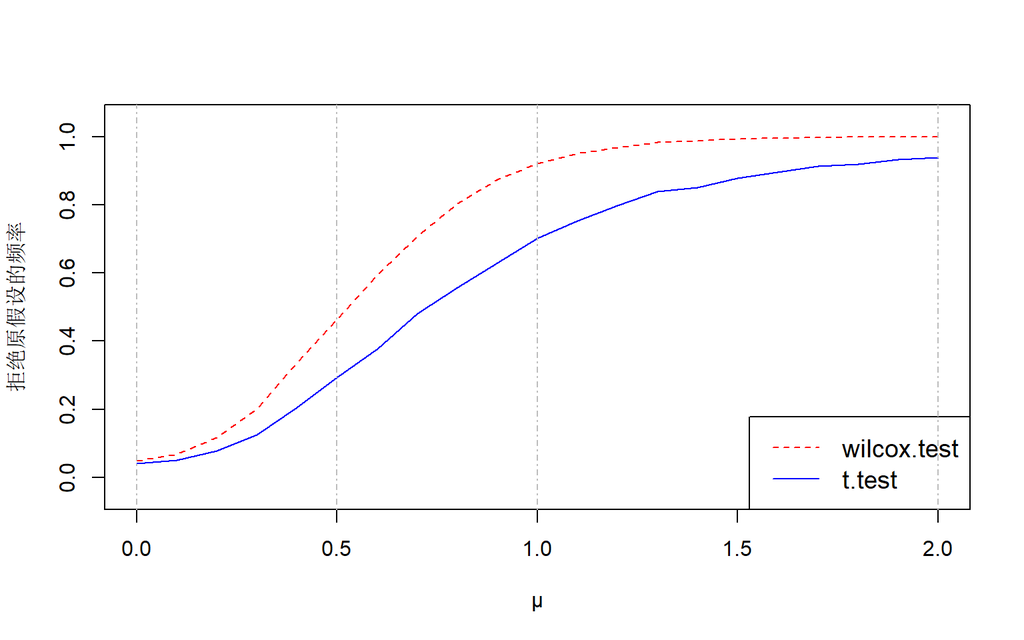

```r
#绘制$\mu$在$[0,2]$变动下的图像
plot(mu_range,t_range,type='l',col='blue',xlab='μ',ylab='拒绝原假设的频率',family='PingFang SC',ylim=c(-0.05,1.05))
lines(mu_range,wil_range,lty=2,col='red')
legend("bottomright",c("wilcox.test","t.test"),
       lty=c(2,1),col=c('red','blue'),cex=1.2)#图例
abline(v=c(0,0.5,1,2),lty=4,col='grey')
```

分别在均值为$\mu=0,0.5,1,2$下生成t分布的随机样本，取显著性水平$\alpha=0.05$，对如下检验问题：
$$H_0:\mu=0\quad v.s.\quad H_1:\mu\neq0$$
进行检验。上表得到的是10000次检验中每个检验得到拒绝原假设的结果的频率。同时为进一步研究两种检验拒绝原假设的频率随$\mu$的变化情况，使得$\mu$在$[0,2]$变动，**绘制图像如上图所示**，观察图像得到结论：

对于这一问题，

（1）当$\mu=0$时，这时零假设为真。Wilcoxon符号秩检验不依赖分布，所以拒绝原假设的频率十分接近显著性水平$\alpha$。由于生成的随机样本服从自由度为2的t分布，均值为0，由中心极限定理，这30个数据的均值近似服从均值为0的正态分布，因此使用t检验对这组数据的均值进行检验能够得到更好的检验结果（拒绝原假设的频率更低）。

（2）当$\mu=0.5,1,2$时，这时零假设不真，可以看到Wilcoxon符号秩检验比t检验更有效，特别是在$0.5<\mu<1.5$内，Wilcoxon符号秩检验拒绝原假设的频率显著地高于t检验，而在$\mu>1.5$后，由于二者拒绝原假设的频率都已超过0.9，导致二者差距逐渐减小（如上图）。